# Modelos GARCH

Javier López

28/5/2020

Problemas recientes en finanzas ha motivado el estudio de la volatilidad o variabilidad de series temporales. Recordemos que los modelos **ARMA** asumen varianza constante, luego se debe plantear una alternativa para medir los cambios en la volatilidad, estos modelos son los Autoregresivos Condicionales Heterocedásticos **ARCH**, fueron dados por Engle en 1982 y extendidos a **GARCH**.

**Tasa de crecimiento o retorno:** Sea $x_t$ el valor de la variable de la serie de tiempo, luego el retorno lo definimos como:
$$y_t = \dfrac{x_t-x_{t-1}}{x_{t-1}}$$
Si el retorno representa un cambio pequeño en el porcentaje, entonces $\bigtriangledown[ln(x_t)]\approx y_t$. Así, el objetivo del modelo **GARCH** es el estudio de $y_t$.

Usualmente los retornos $y_y$ no tienen varianza constante y grandes periodos con tendencía volatil.

```r
#################################################################
#################################################################
#####   Programa Clase 9 - Series de Tiempo                  ####
#####   Fecha de creación: 20200528                          ####
#####   Fecha de última edición: 20200528                    ####
#####   Autor: Edgar Javier López Moreno                     ####
#####   E-mail: edgar.lopez@libertadores.edu.co              ####
#################################################################
#################################################################

rm(list = ls())

#################################################################
#####                   Librerias utilizadas                #####
#################################################################

library(astsa)
library(tseries)

#################################################################
#####                  Carga de información                #####
#################################################################

data(nyse)
```

Un ejemplo de este caso son los retornos diarios de la bolsa de valores de New York *(New York Stock Exchange - NYSE)*, información del 2 de febrero de 1984 a 31 de diciembre de 1991. Este es un caso tipico donde el retorno $y_t$ es estable excepto en un punto como se muestra en la siguiente gráfica.

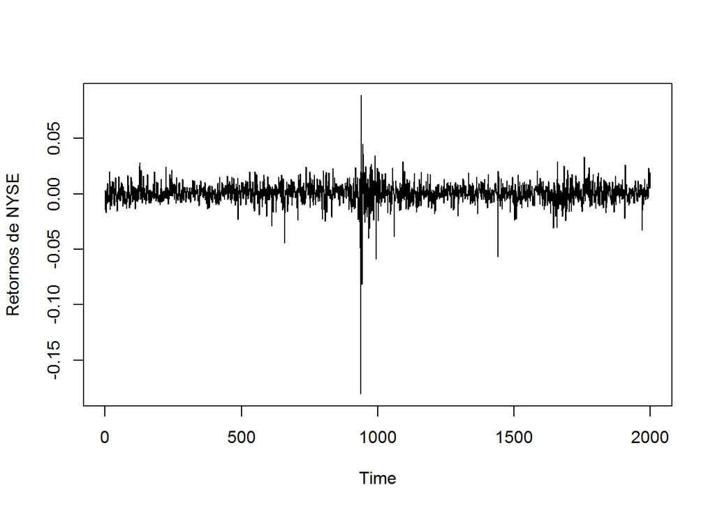

```r
#################################################################
#####                   Ejecución Programa                  #####
#################################################################

plot(nyse, ylab="Retornos de NYSE")
```

## Modelos ARCH

El modelo $ARCH(1)$ se define como:
$$\begin{align*}
y_t &= \sigma_t \epsilon_t\\
\sigma_t^2 &= \alpha_0 + \alpha_1 y_{t-1}^2
\end{align*}$$
Donde $\epsilon_t \sim iid \;\ N(0,1)$. Este modelo parte de un procesos de ruido blanco con varianza condicional no constante, como se puede ver la varianza condicional depende del retorno anterior.
Note que la distribución condicional de $y_t$ dado $y_{t-1}$ está dado por:
$$y_t|y_{t-1}\sim N(0, \alpha_0 + \alpha_1 y_{t-1}^2)$$
Luego es posible escribir el $ARCH(1)$ como $AR(1)$:
$$y_t^2= \alpha_0+\alpha_1y_{t-1}^2+v_t$$
Donde $v_t=\sigma_t^2(\epsilon_t^2-1)$. Como $\epsilon_t^2$ es el cuadrado de una $N(0,1)$, entonces $\epsilon_t^2-1\sim \chi_{(1)}^2$.

#### **Propiedades de ARCH(1)**

Si $0\leq \alpha_1 \leq 1$, el proceso $y_t$ en sí es ruido blanco y su distribución no condicional es simétrica alrededor de cero; esta distribución es leptocúrtica.

Si $3\alpha_1^2<1$, $y_t^2$ sigue un modelo $AR(1)$ con ACF dada por: $\rho_{y^2}(h)= \alpha_1^h \geq 0$, para todo $h>0$.

#### **Simulación de un ARCH(2)**

$$\begin{align*}
y_t &= \sigma_t \epsilon_t\\
\sigma_t^2 &= \alpha_0 + \alpha_1 y_{t-1}^2 + \alpha_2 y_{t-2}^2
\end{align*}$$
con $\alpha_0=0.1$, $\alpha_1=0.5$, $\alpha_2=0.2$, tenemos que:

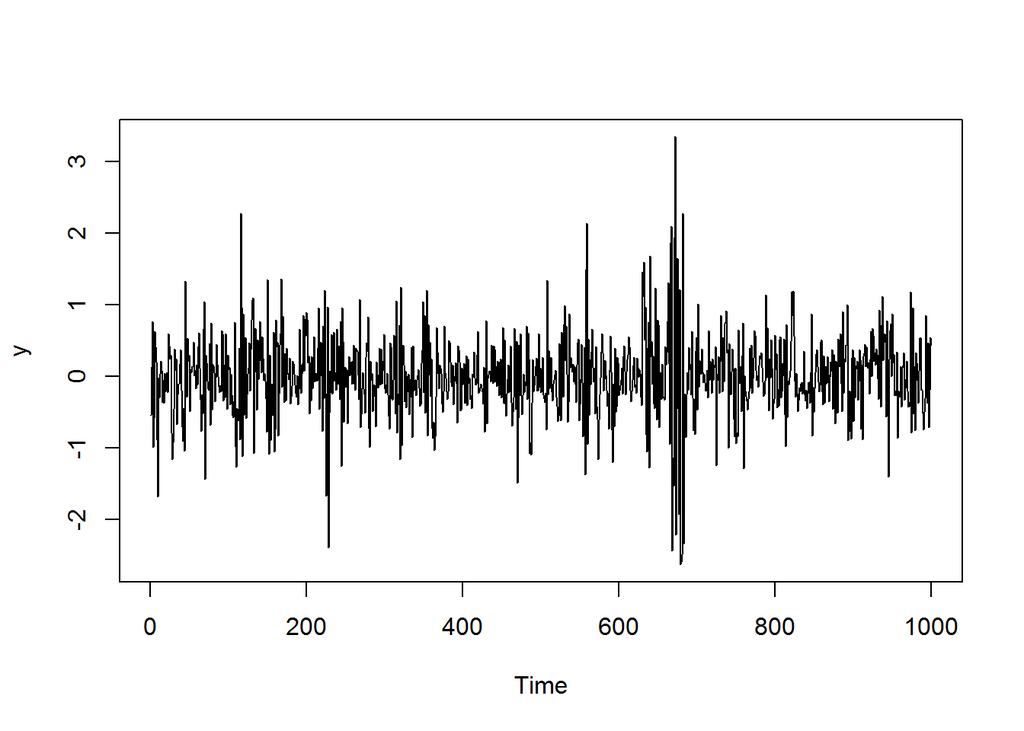

```r
n <- 1100
a <- c(0.1, 0.5, 0.2)  # ARCH(2) coefficients
e <- rnorm(n)
y <- double(n)
y[1:2] <- rnorm(2, sd = sqrt(a[1]/(1.0-a[2]-a[3])))
for(i in 3:n) y[i] <- e[i]*sqrt(a[1] + a[2]*y[i-1]^2 + a[3]*y[i-2]^2)
y <- ts(y[101:1100])
plot(y)
```

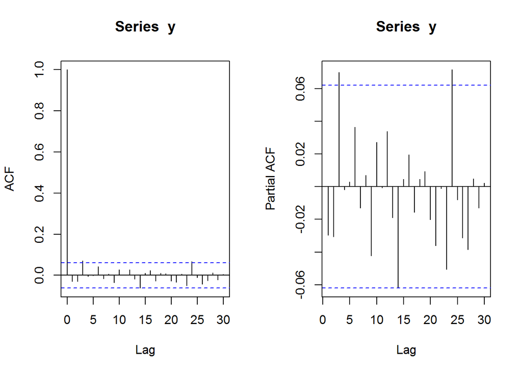

```r
par(mfrow=c(1,2))
acf(y)
pacf(y)
```

```r
y.arch <- garch(y, order = c(0,2))  # Fit ARCH(2)
```

[output not shown]

```r
summary(y.arch)                     # Diagnostic tests
```

```
##
## Call:
## garch(x = y, order = c(0, 2))
##
## Model:
## GARCH(0,2)
##
## Residuals:
##      Min       1Q   Median       3Q      Max
## -2.84292 -0.66507 -0.01792  0.65839  3.39976
##
## Coefficient(s):
##     Estimate  Std. Error  t value Pr(>|t|)
## a0   0.09517     0.01010    9.420  < 2e-16 ***
## a1   0.54787     0.06971    7.859 3.77e-15 ***
## a2   0.21191     0.05416    3.913 9.12e-05 ***
## ---
## Signif. codes:  0 '***' 0.001 '**' 0.01 '*' 0.05 '.' 0.1 ' ' 1
##
## Diagnostic Tests:
##  Jarque Bera Test
##
## data:  Residuals
## X-squared = 3.5364, df = 2, p-value = 0.1706
##
##
##  Box-Ljung test
##
## data:  Squared.Residuals
## X-squared = 0.45399, df = 1, p-value = 0.5004
```

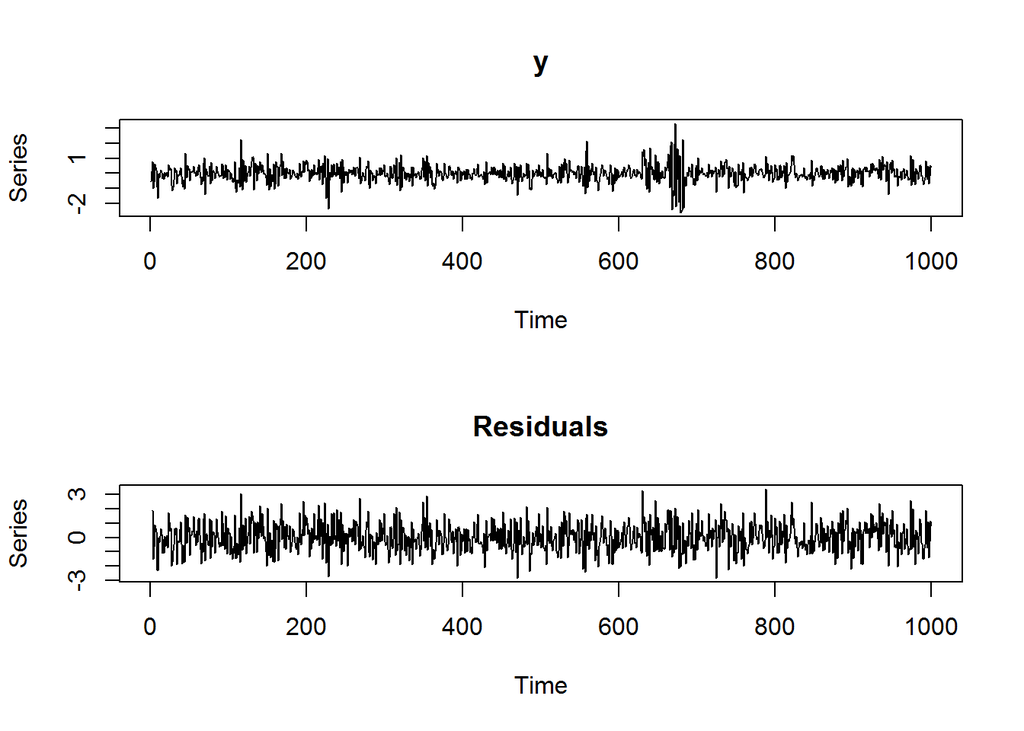

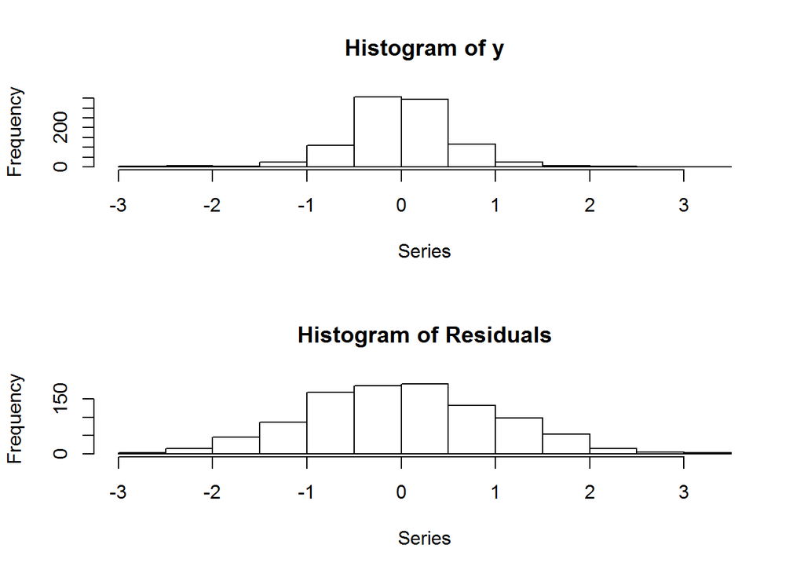

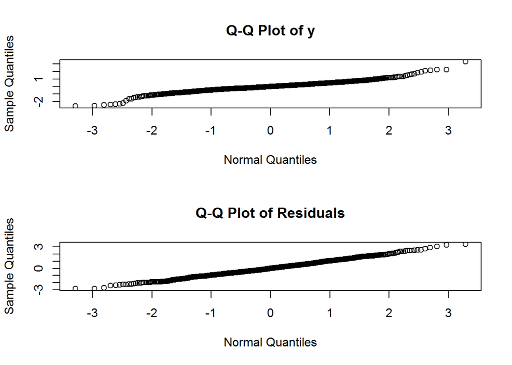

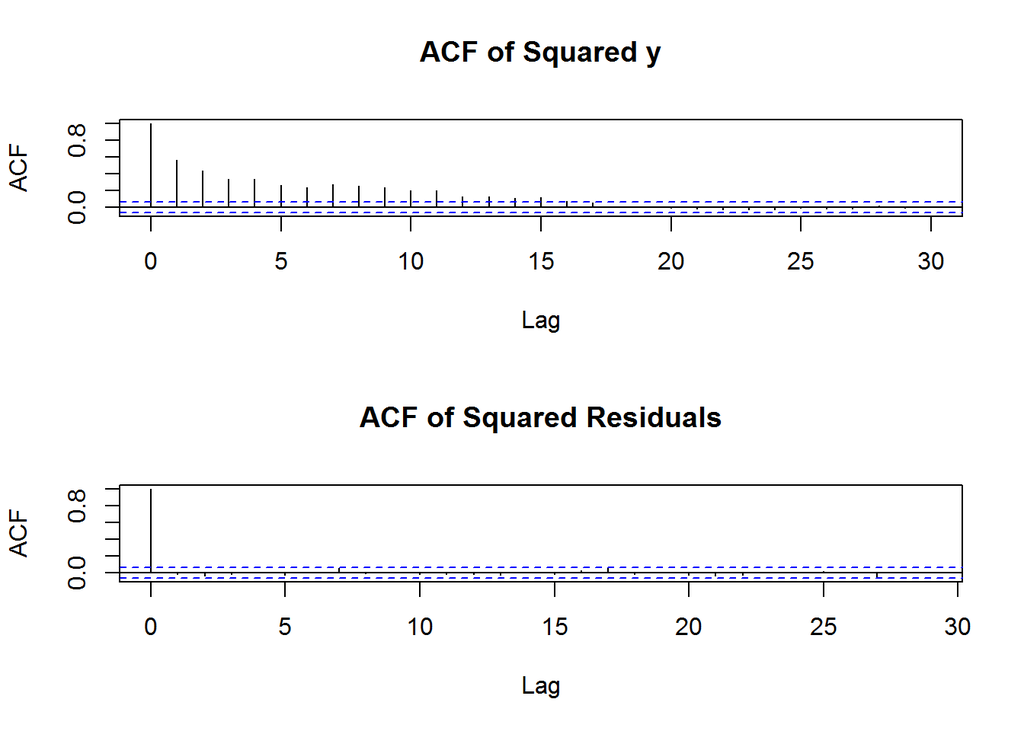

```r
plot(y.arch)
```

### Ejemplo Producto Nacional Bruto en Estados Unidos (US GNP)

Analizaremos inicialmente desde un modelo $ARIMA$ el $US-GNP$ trimestral, desde el primer trimestre de 1947 al tercer trimestre de 2002. Lo datos son obtenidos de la Reserva Federal del Banco de St. Louis (http://research.stlouisfed.org/).

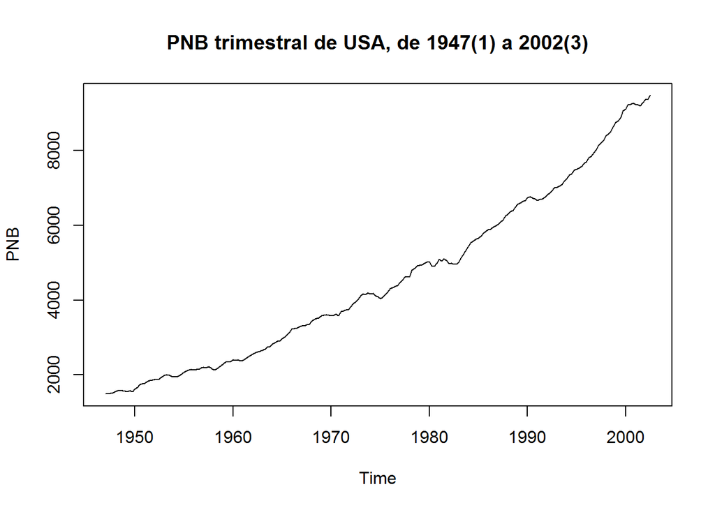

```r
data("gnp")
plot(gnp, ylab="PNB", main = "PNB trimestral de USA, de 1947(1) a 2002(3)")
```

Analizando el ACF de $y_t$, tenemos que

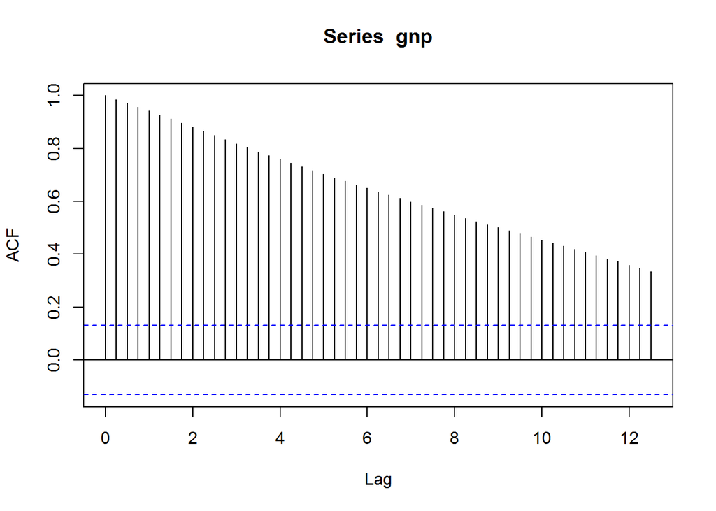

```r
acf(gnp, 50)
```

Vemos necesario realizar la diferencia del logaritmo de $y_t$:

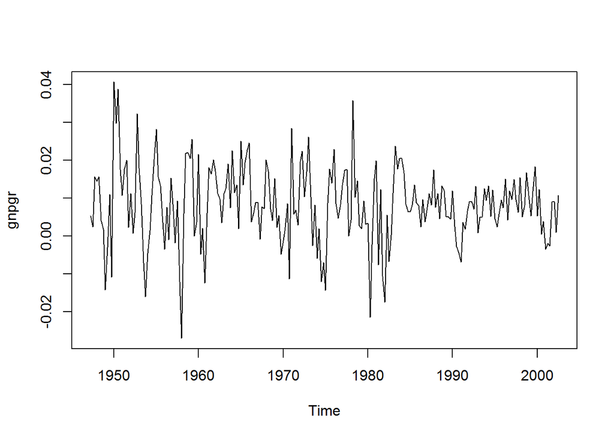

```r
gnpgr <- diff(log(gnp))
plot.ts(gnpgr)
```

Así tenemos el ACF y PACF de $\bigtriangledown log(y_t)$:

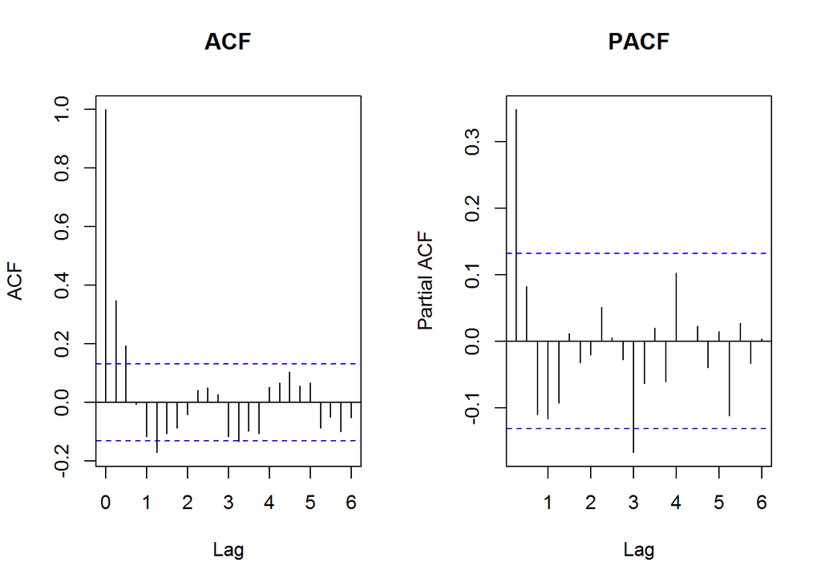

```r
par(mfrow=c(1,2))
acf(gnpgr, 24, main = 'ACF')
pacf(gnpgr, 24, main = 'PACF')
```

Luego, para $\bigtriangledown log(y_t)$ sugerimos especificar un $MA(2)$ o un $ARIMA(0,1,2)$ para $log(y_t)$, pero también es cierto que el ACF está disminuyendo y el PACF se está cortando en el retraso 1, luego se sugiere un $AR(1)$ o $ARIMA(1,1,0)$ para el logaritmo de PNB de USA.

#### Escenario $ARIMA(0,1,2)$

Vamos a realizar los diagnosticos del modelo propuesto:

```r
gnpgr.ma <- arima(gnpgr, order = c(0, 0, 2))
gnpgr.ma
```

```
##
## Call:
## arima(x = gnpgr, order = c(0, 0, 2))
##
## Coefficients:
##          ma1     ma2  intercept
##       0.3028  0.2035     0.0083
## s.e.  0.0654  0.0644     0.0010
##
## sigma^2 estimated as 8.919e-05:  log likelihood = 719.96,  aic = -1431.93
```

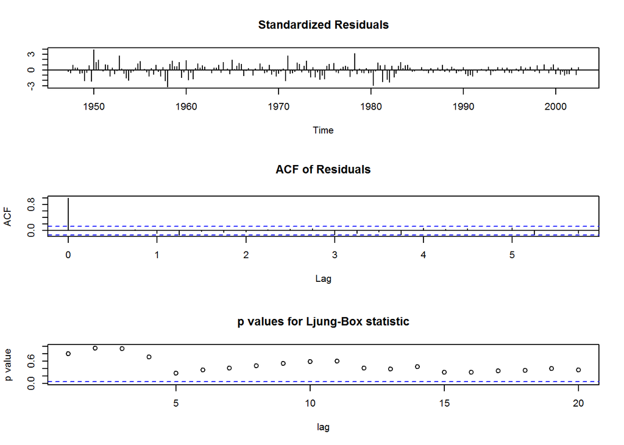

```r
tsdiag(gnpgr.ma, gof.lag=20)
```

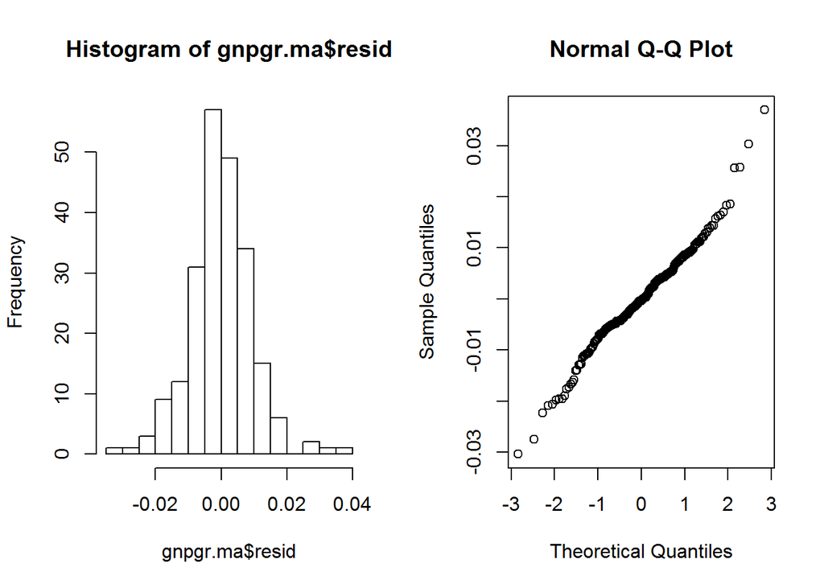

```r
par(mfrow=c(1,2))
hist(gnpgr.ma$resid, br=12)
qqnorm(gnpgr.ma$resid)
```

```r
shapiro.test(gnpgr.ma$resid)
```

```
##
##  Shapiro-Wilk normality test
##
## data:  gnpgr.ma$resid
## W = 0.98029, p-value = 0.003416
```

#### Escenario $ARIMA(1,1,0)$

Vamos a realizar los diagnosticos del modelo propuesto:

```r
gnpgr.ar = arima(gnpgr, order = c(1, 0, 0))
gnpgr.ar
```

```
##
## Call:
## arima(x = gnpgr, order = c(1, 0, 0))
##
## Coefficients:
##          ar1  intercept
##       0.3467     0.0083
## s.e.  0.0627     0.0010
##
## sigma^2 estimated as 9.03e-05:  log likelihood = 718.61,  aic = -1431.22
```

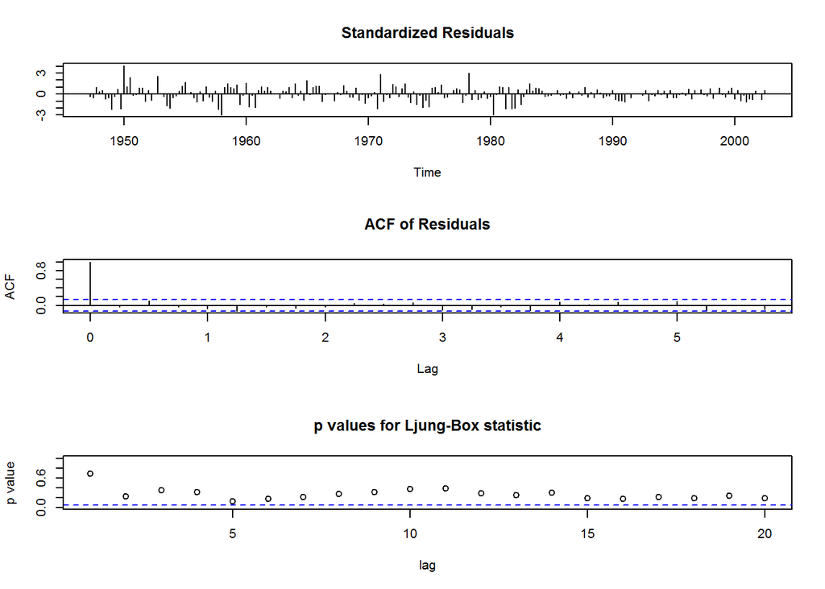

```r
tsdiag(gnpgr.ar, gof.lag=20)
```

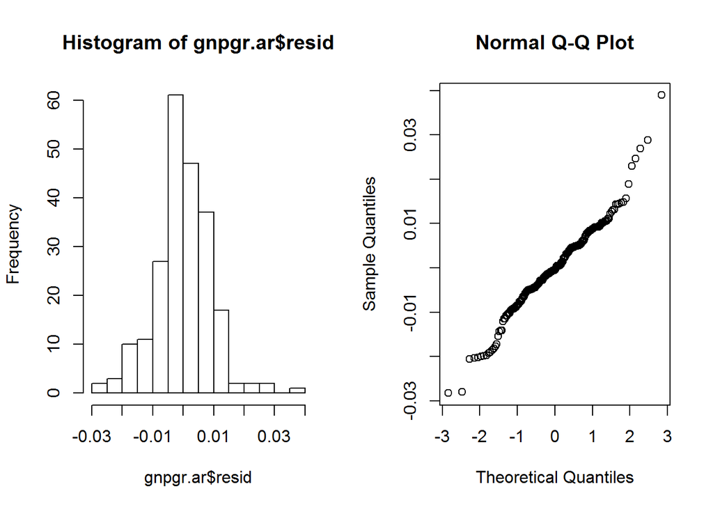

```r
par(mfrow=c(1,2))
hist(gnpgr.ar$resid, br=12)
qqnorm(gnpgr.ar$resid)
```

```r
shapiro.test(gnpgr.ar$resid)
```

```
##
##  Shapiro-Wilk normality test
##
## data:  gnpgr.ar$resid
## W = 0.9756, p-value = 0.0006885
```

Luego comparando por criterios de información, tenemos que:

```r
gnpgr.ma$aic
```

```
## [1] -1431.929
```

```r
gnpgr.ar$aic
```

```
## [1] -1431.221
```

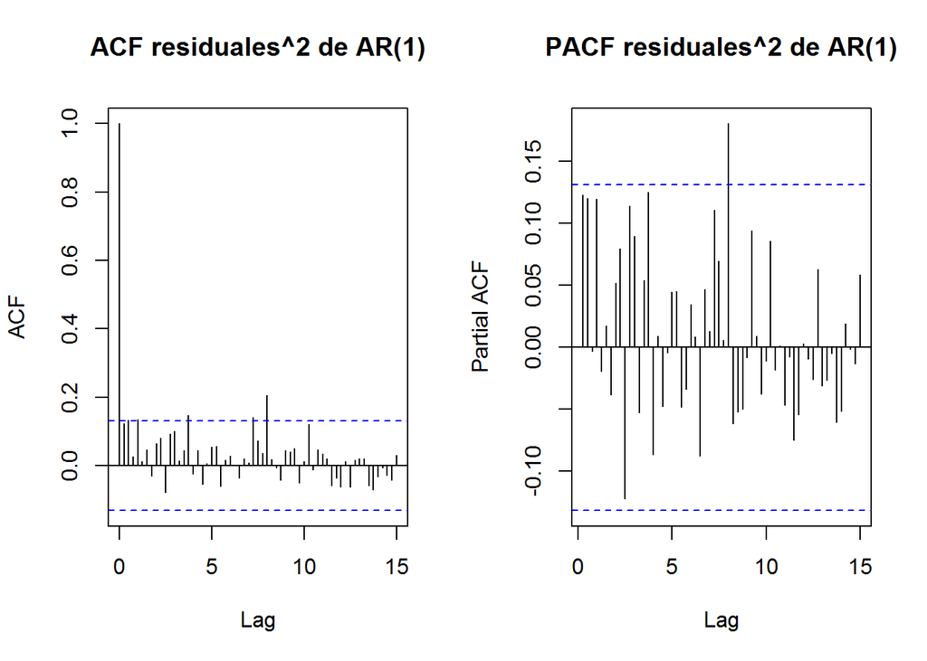

```r
par(mfrow=c(1,2))
acf(residuals(gnpgr.ar)^2, 60, main = 'ACF residuales^2 de AR(1)')
pacf(residuals(gnpgr.ar)^2, 60, main = 'PACF residuales^2 de AR(1)')
```

Luego especificamos un $AR(1)-ARCH(1)$, obteniendo los siguientes resultados:

```r
gnpr.ar <- ar.mle(gnpgr, order.max=1) # Recuerde phi_1 = 0.347
gnpr.ar
```

```
##
## Call:
## ar.mle(x = gnpgr, order.max = 1)
##
## Coefficients:
##      1
## 0.3466
##
## Order selected 1  sigma^2 estimated as  9.03e-05
```

```r
y       <- gnpr.ar$resid[2:length(gnpgr)] # first resid is NA
arch.y  <- garch(y, order = c(0,1))
```

[output not shown]

```r
summary(arch.y)
```

```
##
## Call:
## garch(x = y, order = c(0, 1))
##
## Model:
## GARCH(0,1)
##
## Residuals:
##      Min       1Q   Median       3Q      Max
## -3.21636 -0.54732 -0.03107  0.59886  3.34757
##
## Coefficient(s):
##     Estimate  Std. Error  t value Pr(>|t|)
## a0 7.403e-05   7.275e-06   10.175  < 2e-16 ***
## a1 1.939e-01   6.781e-02    2.859  0.00425 **
## ---
## Signif. codes:  0 '***' 0.001 '**' 0.01 '*' 0.05 '.' 0.1 ' ' 1
##
## Diagnostic Tests:
##  Jarque Bera Test
##
## data:  Residuals
## X-squared = 8.4801, df = 2, p-value = 0.01441
##
##
##  Box-Ljung test
##
## data:  Squared.Residuals
## X-squared = 0.00028559, df = 1, p-value = 0.9865
```

El modelo se puede extender hasta el orden $m$, así $ARCH(m)$:
$$\begin{align*}
y_t &= \sigma_t \epsilon_t\\
\sigma_t^2 &= \alpha_0 + \alpha_1 y_{t-1}^2 + ... +\alpha_m y_{t-m}^2
\end{align*}$$
El modelo $GARCH$ lo podemos ver como una extensión de los modelos $ARCH$, así tenemos que un $GARCH(m,r):$
$$\begin{align*}
y_t &= \sigma_t \epsilon_t\\
\sigma_t^2 &= \alpha_0 + \sum_{i=1}^{m} \alpha_i y_{t-i}^2 + \sum_{j=1}^{r} \beta_j \sigma_{t-j}^2
\end{align*}$$

### Ejemplo Analísis GARCH en los retornos NYSE

Tenemos que los retornos tienen un comportamiento clásico de los modelos $GARCH$:

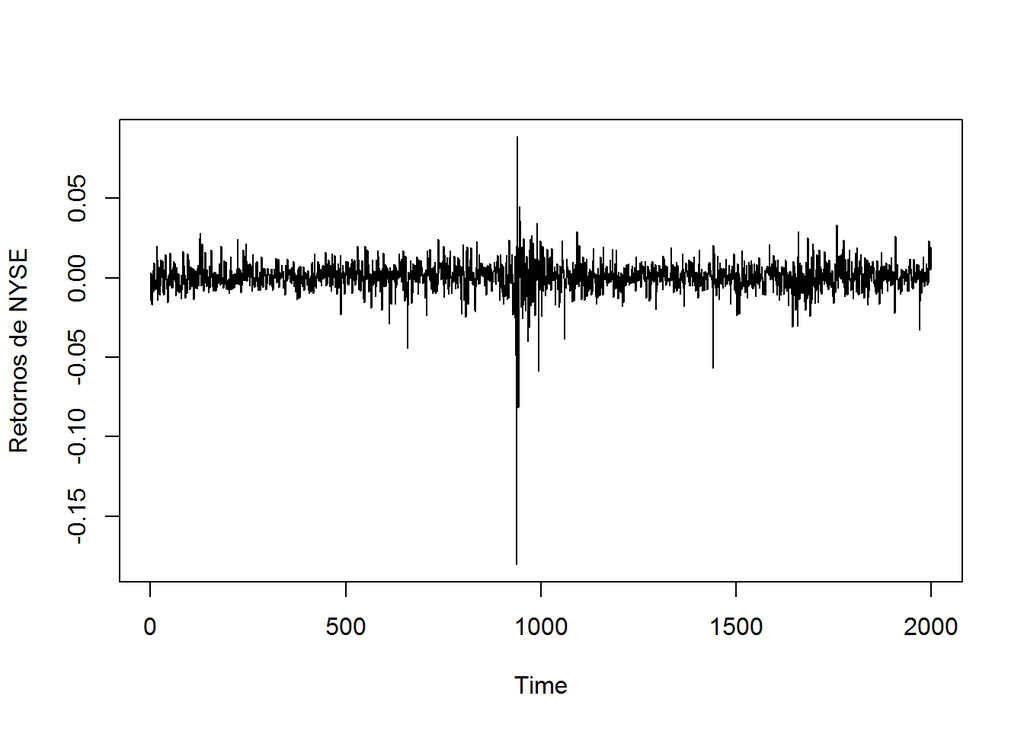

```r
plot(nyse, ylab="Retornos de NYSE")
```

Luego, sugerimos un modelo $GARCH(1,1)$:

```r
nyse.g <- garch(nyse, order=c(1,1))
```

[output not shown]

```r
summary(nyse.g)
```

```
##
## Call:
## garch(x = nyse, order = c(1, 1))
##
## Model:
## GARCH(1,1)
##
## Residuals:
##      Min       1Q   Median       3Q      Max
## -8.66460 -0.45228  0.08785  0.59918  4.07508
##
## Coefficient(s):
##     Estimate  Std. Error  t value Pr(>|t|)
## a0 6.552e-06   6.761e-07    9.691   <2e-16 ***
## a1 1.118e-01   4.056e-03   27.554   <2e-16 ***
## b1 8.086e-01   1.292e-02   62.566   <2e-16 ***
## ---
## Signif. codes:  0 '***' 0.001 '**' 0.01 '*' 0.05 '.' 0.1 ' ' 1
##
## Diagnostic Tests:
##  Jarque Bera Test
##
## data:  Residuals
## X-squared = 3983.9, df = 2, p-value < 2.2e-16
##
##
##  Box-Ljung test
##
## data:  Squared.Residuals
## X-squared = 1.5874, df = 1, p-value = 0.2077
```

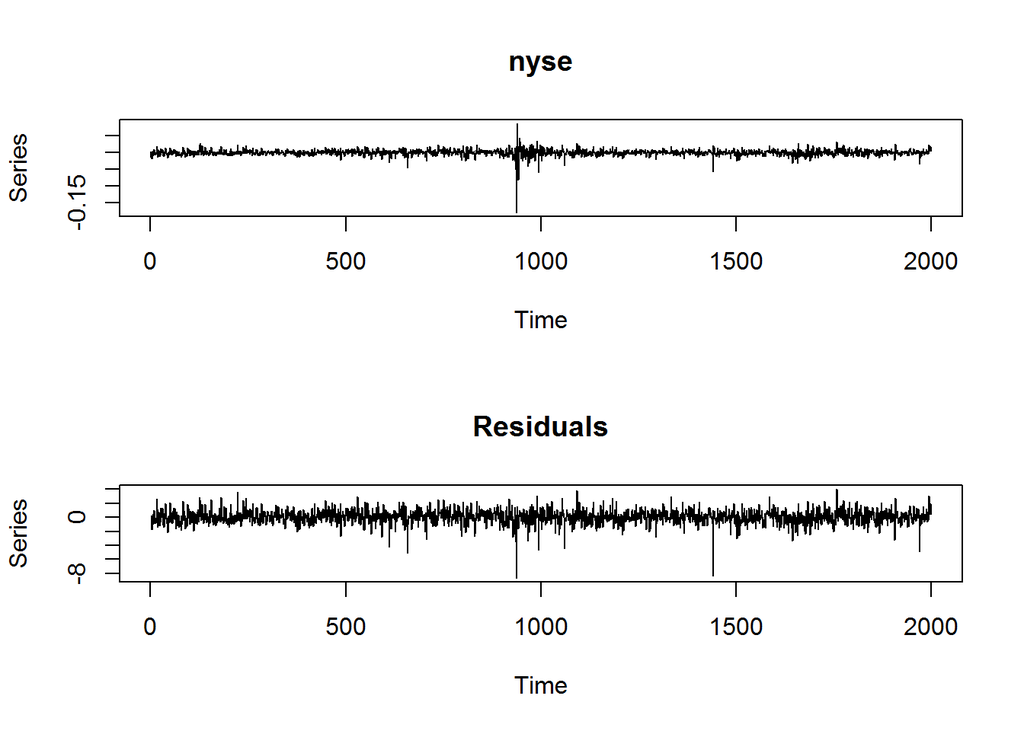

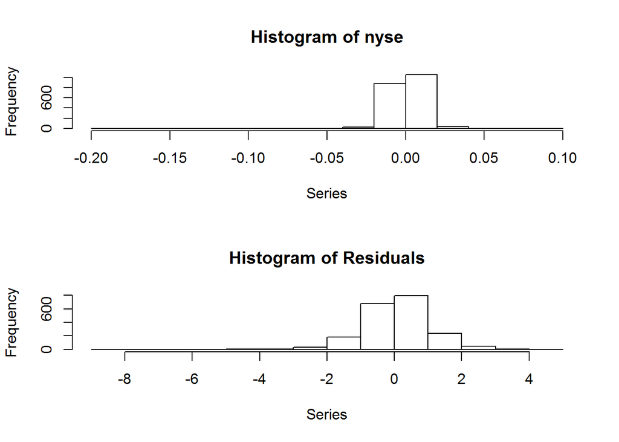

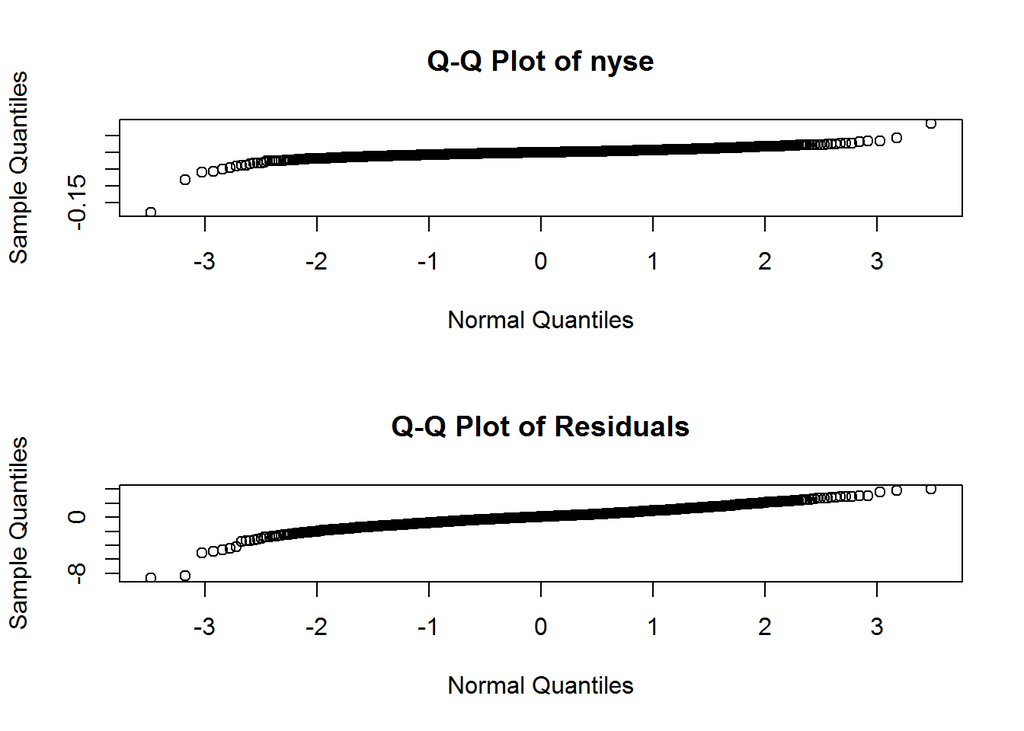

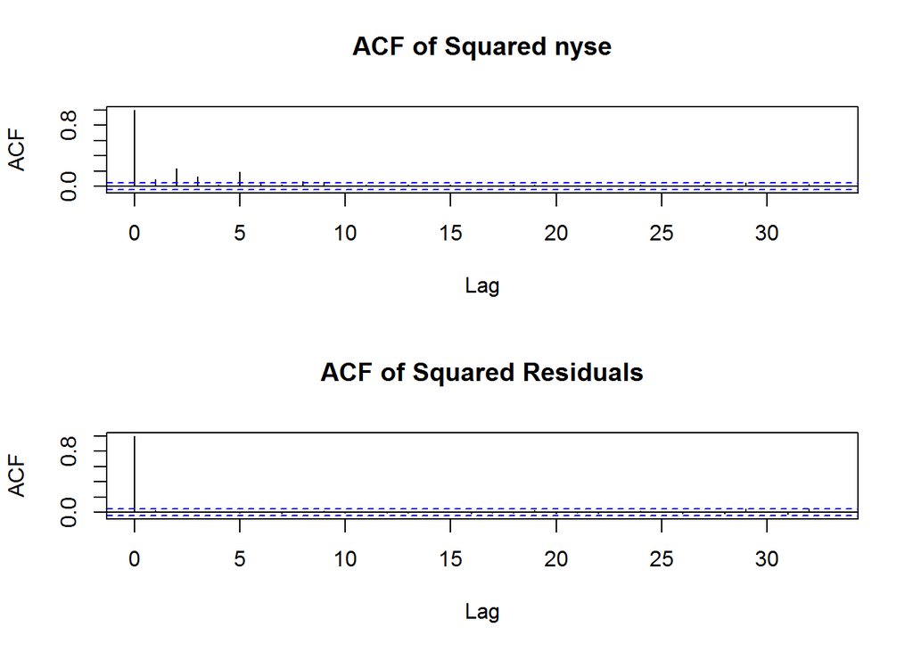

```r
plot(nyse.g)
```

Vemos que los parametros son significativos, sin embargo el supuesto de normalidad no se cumple. Analizando las predicciones de los modelos $GARCH$, tenemos las predicciones correspondientes a la volatilidad de $\sigma_t^2$, los resultados se ven en las lineas azules de la siguiente grafica:

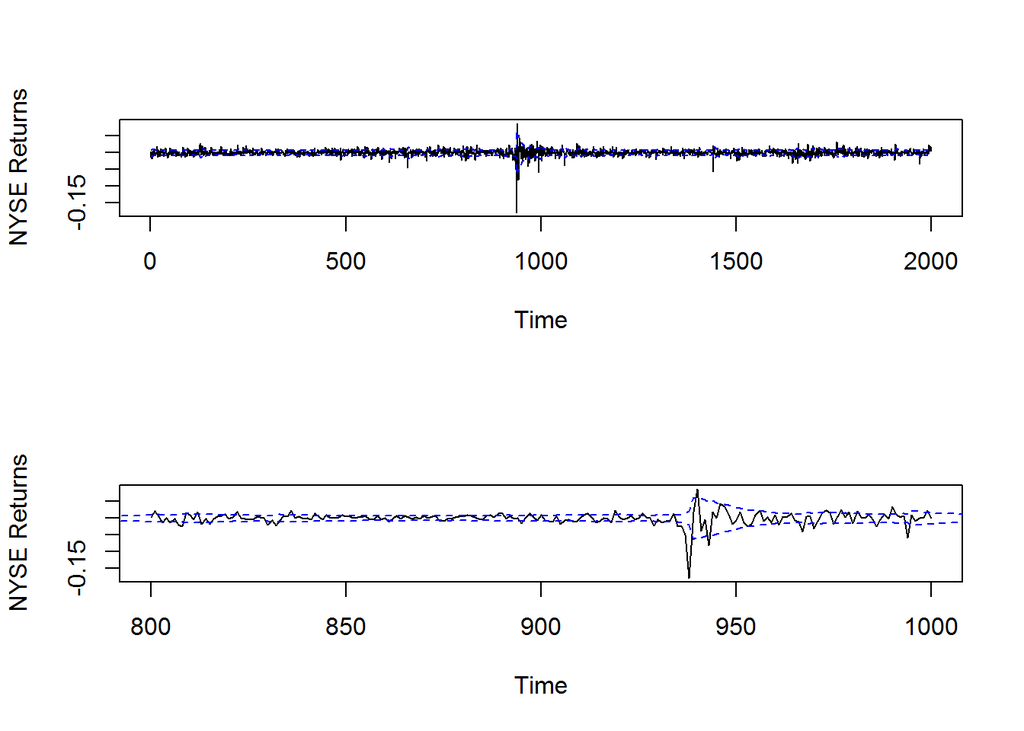

```r
u <- predict(nyse.g)

par(mfrow=c(2,1))
plot(nyse, type="l", xlab="Time", ylab="NYSE Returns")
lines(u[,1], col="blue", lty="dashed")
lines(u[,2], col="blue", lty="dashed")

plot(800:1000, nyse[800:1000], type="l", xlab="Time", ylab="NYSE Returns")
lines(u[,1], col="blue", lty="dashed")
lines(u[,2], col="blue", lty="dashed")
```

Es evidente que la distribución condicional de los retornos rara vez es normal. En particular, aparte de la distribución gaussiana (el valor predeterminado), otras adecuaciones del modelo Garch permite distribuciones condicionales t, doble exponencial y doble exponencial generalizadas. Además, las predicciones que se muestraron anteriormente dejan algo que desear. Parece que el modelo es mejor para decirle cuál fue la volatilidad en lugar de cuál será; básicamente, los aumentos o disminuciones en la volatilidad pronosticada se retrasan un día.

Una gran alternativa esinvestigar los diversos mdelos $EGARCH$, $IGARCH$ y las posibles comnibaciones con los modelos $ARMA$, por esta razón presentamos la libreria *rugarch* donde se pueden especificar diversos modelos y de manera rapida se pueden realizar los diagnoticos y pronosticos:

```r
library(rugarch)
```

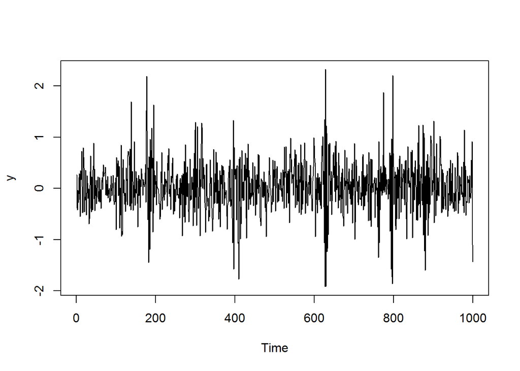

```r
n <- 1100
a <- c(0.1, 0.5, 0.2)  # ARCH(2) coefficients
e <- rnorm(n)
y <- double(n)
y[1:2] <- rnorm(2, sd = sqrt(a[1]/(1.0-a[2]-a[3])))
for(i in 3:n) y[i] <- e[i]*sqrt(a[1] + a[2]*y[i-1]^2 + a[3]*y[i-2]^2)
y <- ts(y[101:1100])
plot(y)
```

```r
model.sim <- ugarchspec(variance.model = list(model = "sGARCH", garchOrder = c(2, 0)),
                   mean.model = list(armaOrder = c(0, 0), include.mean = FALSE),
                   distribution.model = "norm")
fit.sim   <- ugarchfit(model.sim, y)
fit.sim
```

```
##
## *---------------------------------*
## *          GARCH Model Fit        *
## *---------------------------------*
##
## Conditional Variance Dynamics
## -----------------------------------
## GARCH Model  : sGARCH(2,0)
## Mean Model   : ARFIMA(0,0,0)
## Distribution : norm
##
## Optimal Parameters
## ------------------------------------
##         Estimate  Std. Error  t value Pr(>|t|)
## omega   0.090441    0.008629  10.4807 0.000000
## alpha1  0.517975    0.070670   7.3295 0.000000
## alpha2  0.166156    0.047332   3.5105 0.000447
##
## Robust Standard Errors:
##         Estimate  Std. Error  t value Pr(>|t|)
## omega   0.090441    0.008756  10.3291 0.000000
## alpha1  0.517975    0.064123   8.0779 0.000000
## alpha2  0.166156    0.045256   3.6715 0.000241
##
## LogLikelihood : -600.0582
##
## Information Criteria
## ------------------------------------
##
## Akaike       1.2061
## Bayes        1.2208
## Shibata      1.2061
## Hannan-Quinn 1.2117
##
## Weighted Ljung-Box Test on Standardized Residuals
## ------------------------------------
##                         statistic p-value
## Lag[1]                     0.2133 0.64422
## Lag[2*(p+q)+(p+q)-1][2]    2.1990 0.23177
## Lag[4*(p+q)+(p+q)-1][5]    6.9750 0.05259
```

[output cut: 34 more lines]

```
## Negative Sign Bias  0.3388 0.7348
## Positive Sign Bias  0.9554 0.3396
## Joint Effect        1.7193 0.6327
##
##
## Adjusted Pearson Goodness-of-Fit Test:
## ------------------------------------
##   group statistic p-value(g-1)
## 1    20     28.92      0.06725
## 2    30     38.96      0.10243
## 3    40     56.40      0.03524
## 4    50     54.30      0.27960
##
##
## Elapsed time : 0.2161531
```

```r
#plot(fit.sim)

fspec.sim <- getspec(fit.sim)
setfixed(fspec.sim) <- as.list(coef(fit.sim))

m <- ceiling(100 / 10)
pred.sim <- ugarchforecast(fspec.sim, data = y, n.ahead = 50, n.roll = m-1, out.sample = m)
#plot(pred.sim)
```